# 모델링 2 (Python)

# 실습

## 1. 분석을 위해 필요한 라이브러리 및 데이터 불러오기

- Python에서는 pandas, seaborn, matplotlib, scikit-learn, tensorflow 등을 사용합니다.

```python
import pandas as pd
import numpy as np
import matplotlib.pyplot as plt

import seaborn as sns
sns.set_theme(style="whitegrid", palette="muted")

from sklearn.model_selection import train_test_split
from sklearn.linear_model import LogisticRegression
from sklearn.tree import DecisionTreeClassifier, plot_tree
from sklearn.ensemble import RandomForestClassifier
from sklearn.metrics import roc_curve, auc

import tensorflow as tf
from tensorflow import keras
```

- 그래프에 한글을 출력하고자 할 때에는 한글 폰트를 지정해야 합니다.

```python
!apt-get -qq install fonts-nanum
```

[output not shown]

```python
from matplotlib import rc
rc('font', family='NanumGothic') # 그래프에 한글 출력시 폰트 지정해야 함
```

```python
# SPSS 데이터 불러오기
hn19 = pd.read_csv("HN19_lec3.csv")
hn19.head(n = 5)
```

|  | age | HE_BMI | HE_HP | HE_DM_HbA1c |
| --- | --- | --- | --- | --- |
| 0 | 61 | 25.987394 | 3.0 | 3.0 |
| 1 | 28 | 16.900942 | 1.0 | 1.0 |
| 2 | 53 | 19.781829 | 2.0 | 1.0 |
| 3 | 50 | 26.631647 | 1.0 | 2.0 |
| 4 | 16 | NaN | NaN | NaN |

## 2. 변수 생성 및 결측 처리

- 주어진 데이터로부터 BMI(체질량지수), 고혈압 여부, 당뇨 여부를 나타내는 범주형 변수를 생성합니다.
- 본래 고혈압 여부는 HE_HP에 1 = 정상, 2 = 고혈압 전단계, 3 = 고혈압으로 코딩돼 있는데 이를 hp에 0 = 정상, 1 = 고혈압 전단계 또는 고혈압으로 변환하고, 당뇨 여부는 HE_DM_HbA1c에 1 = 정상, 2 = 당뇨병 전단계, 3 = 당뇨병으로 코딩돼 있는데 이를 diabetes에 0 = 정상, 1 = 당뇨병 전단계 또는 고혈압으로 코딩합니다.
- 결측치(NA)가 포함된 행을 제거합니다.
- 분석에 필요한 변수만 선택합니다.
- `head()`와 동일한 방법으로, `tail()`을 이용해 데이터의 뒷부분을 확인할 수 있으며, `n = 3`과 같이 표시할 행의 수를 명시할 수 있습니다.

```python
hn19 = hn19.assign(
    bmi=hn19['HE_BMI'],
    hp=np.where(hn19['HE_HP'].isin([2,3]), 1, 0),
    diabetes=np.where(hn19['HE_DM_HbA1c'].isin([2,3]), 1, 0)
).dropna(subset=['bmi','hp','diabetes'])[['age','bmi','hp','diabetes']]
hn19.tail(3)
```

|  | age | bmi | hp | diabetes |
| --- | --- | --- | --- | --- |
| 8107 | 43 | 15.375148 | 0 | 0 |
| 8108 | 16 | 14.844970 | 0 | 0 |
| 8109 | 8 | 14.528000 | 0 | 0 |

## 3. 상관관계 분석 및 시각화

```python
corr = hn19[['age','bmi','hp','diabetes']].corr()
```

- 상관계수 행렬을 시각화하기 위해 `seaborn`패키지의 `heatmap()` 함수를 이용합니다.

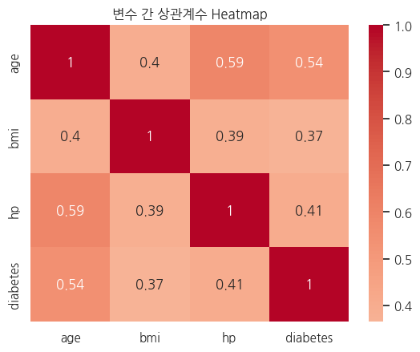

```python
sns.heatmap(corr, annot=True, cmap='coolwarm', center=0)
plt.title("변수 간 상관계수 Heatmap")
plt.show()
```

## 4. BMI와 당뇨병 관계 시각화

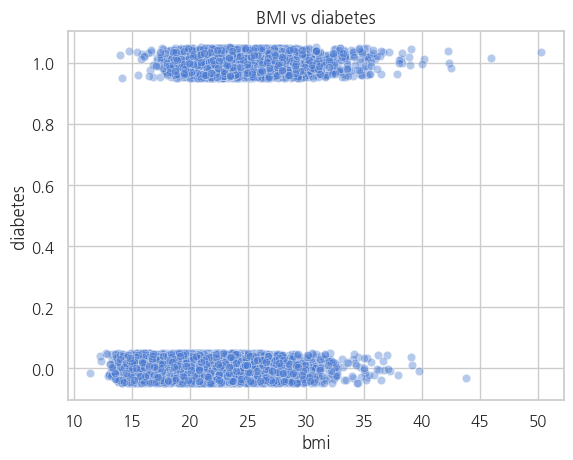

```python
y_jitter = hn19['diabetes'] + np.random.uniform(-0.05, 0.05, size=len(hn19))

sns.scatterplot(x='bmi', y=y_jitter, data=hn19, alpha=0.4)
plt.title("BMI vs diabetes")
plt.show()
```

## 5. 로지스틱 회귀 (2변수 모형) 및 예측 확률 시각화

```python
model_logistic_2d = LogisticRegression(max_iter=1000)
model_logistic_2d.fit(hn19[['age','bmi']], hn19['diabetes'])
```

```
LogisticRegression(max_iter=1000)
```

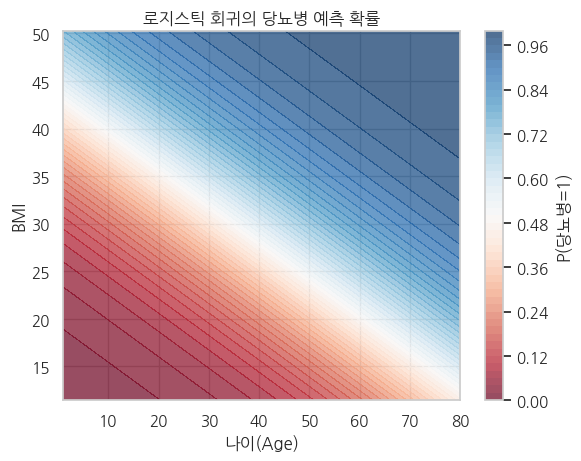

```python
# grid 생성
age_seq = np.linspace(hn19['age'].min(), hn19['age'].max(), 100)
bmi_seq = np.linspace(hn19['bmi'].min(), hn19['bmi'].max(), 100)
A, B = np.meshgrid(age_seq, bmi_seq)

grid = pd.DataFrame({'age': A.ravel(), 'bmi': B.ravel()})
pred_logistic_2d = model_logistic_2d.predict_proba(grid)[:, 1].reshape(A.shape)

contour = plt.contourf(A, B, pred_logistic_2d, levels=50, cmap='RdBu', alpha=0.7)
plt.colorbar(contour, label="P(당뇨병=1)")
plt.xlabel("나이(Age)")
plt.ylabel("BMI")
plt.title("로지스틱 회귀의 당뇨병 예측 확률")
plt.show()
```

```python
model_logistic = LogisticRegression(max_iter=1000)
model_logistic.fit(hn19[['age','bmi','hp']], hn19['diabetes'])
print("회귀계수:", model_logistic.coef_, "절편:", model_logistic.intercept_)
```

```
회귀계수: [[0.05787047 0.15102873 0.34019309]] 절편: [-6.74213772]
```

## 7. 결정 나무 (2변수와 다변량 모델 + 가지치기)

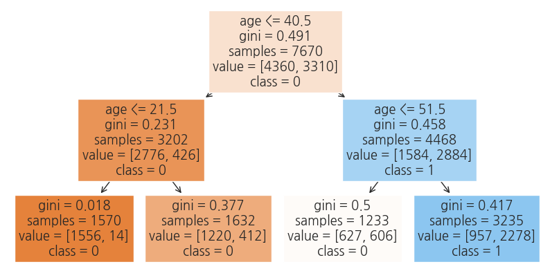

```python
model_tree_2d = DecisionTreeClassifier(max_depth=2, random_state=2025)
model_tree_2d.fit(hn19[['age','bmi']], hn19['diabetes'])

plt.figure(figsize=(10,5))
plot_tree(model_tree_2d, feature_names=['age','bmi'], class_names=['0','1'], filled=True)
plt.show()
```

- 앞에서와 마찬가지로 시각화를 합니다. 격자 데이터는 앞에서 생성한 `grid`를 이용합니다.
- 격자의 각 지점별 당뇨 확률을 계산해 `pred_tree_2d`에 저장합니다.
- `contourf()`을 이용해 색상으로 시각화합니다.
- 결정 나무의 경우에는 경계선이 항상 축과 평행하게 나옴을 알 수 있습니다.

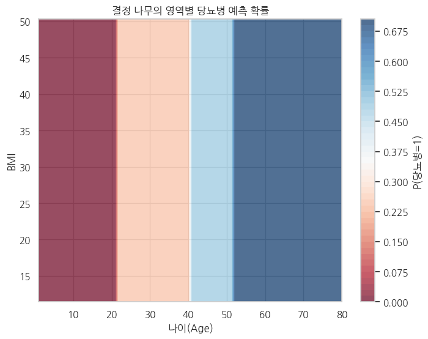

```python
# 2. 결정나무 예측 확률 계산
pred_tree_2d = model_tree_2d.predict_proba(grid)[:, 1].reshape(A.shape)

# 3. 시각화
plt.figure(figsize=(8, 6))
contour = plt.contourf(A, B, pred_tree_2d, levels=50, cmap='RdBu', alpha=0.7)
plt.colorbar(contour, label="P(당뇨병=1)")
plt.xlabel("나이(Age)")
plt.ylabel("BMI")
plt.title("결정 나무의 영역별 당뇨병 예측 확률")
plt.show()
```

- 이번에는 설명변수를 3개 사용하여 `age`, `bmi`, `hp`를 설명변수로, `diabetes`를 반응변수로 하는 분류 결정나무를 적합하고 가지치기(pruning)을 합니다.
- 실행속도 관계상 자료에서 처음 100개의 행만 골라냅니다.
- Python 에서는 결정나무를 가지치기하는 코드가 복잡해, 여기서는 간단하게 복잡도를 조절할 수 있는 파라미터로 결정 나무를 생성합니다. `ccp_alpha` 파라미터를 사용해 결정나무의 복잡도를 조절합니다.

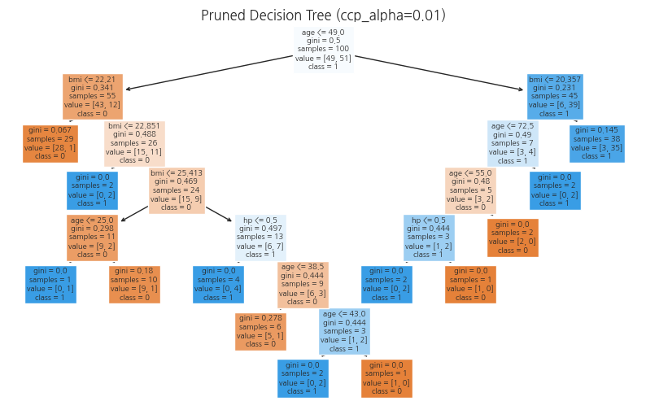

```python
# 가지치기 정도를 alpha(=cp)로 지정 (값이 클수록 많이 가지치기)
model_ptree = DecisionTreeClassifier(random_state=42, ccp_alpha=0.01)
model_ptree.fit(hn19[['age','bmi', 'hp']].iloc[0:100], hn19['diabetes'].iloc[0:100])

# 시각화
plt.figure(figsize=(10, 6))
plot_tree(model_ptree, feature_names=['age','bmi','hp'], class_names=['0','1'], filled=True)
plt.title("Pruned Decision Tree (ccp_alpha=0.01)")
plt.show()
```

## 8. 앙상블 모형 (배깅 & 랜덤 포레스트)

- 배깅(Bagging) 은 여러 부트스트랩 샘플에 대해 모델(결정나무)을 학습하고 예측을 평균/다수결로 결합합니다.
- 랜덤 포레스트(Random Forest) 는 배깅에 변수 무작위 선택을 추가하여 상관성을 줄이고 성능을 향상시킵니다.
- 배깅과 랜덤 포레스트는 모두 `sklearn.ensemble`의 `RandomForestClassifier`로 적합할 수 있습니다. 이는 랜덤 포레스트에서 변수의 개수를 전부 다 쓰면 그게 배깅이 되기 때문입니다.
- 앞에서와 마찬가지로 설명변수를 3개 사용하여 `age`, `bmi`, `hp`를 설명변수로, `diabetes`를 반응변수로 하는 앙상블 모형을 생각합니다.
- 우선 배깅 모형을 적합합니다. 이는 `RandomForestClassifier` 에서 사용하는 설명변수의 개수를 전체 설명변수의 개수인 3으로 지정하면 됩니다 (max_features=3).

```python
model_bag = RandomForestClassifier(n_estimators=100, max_features=3, random_state=42)
model_bag.fit(hn19[['age','bmi', 'hp']], hn19['diabetes'])
```

```
RandomForestClassifier(max_features=3, random_state=42)
```

```python
model_rf = RandomForestClassifier(n_estimators=100, max_features=2, random_state=2025)
model_rf.fit(hn19[['age','bmi', 'hp']], hn19['diabetes'])
```

```
RandomForestClassifier(max_features=2, random_state=2025)
```

## 9. 신경망 모형 (Neural Network)

```python
X_nn = hn19[['age','bmi','hp']].iloc[0:100].values
y_nn = hn19['diabetes'].iloc[0:100].values

model_nn = keras.Sequential([
    keras.layers.Dense(2, activation='relu', input_shape=(3,)),
    keras.layers.Dense(1, activation='sigmoid')
])
model_nn.compile(optimizer='adam', loss='binary_crossentropy', metrics=['accuracy'])
model_nn.fit(X_nn, y_nn, epochs=50, verbose=0)
print("신경망 정확도:", model_nn.evaluate(X_nn, y_nn, verbose=0)[1])
```

```
신경망 정확도: 0.49000000953674316
```

## 10. 모델 평가 (데이터 분리, Threshold 성능 분석, ROC Curve)

- 혼동행렬, 민감도, 특이도(Slide 60~64)로 모델 성능을 평가합니다.
- threshold 변화에 따른 민감도·특이도 변화(ROC Curve)를 시각화하고, AUC를 계산해 분류기 성능을 종합적으로 판단합니다.

- 학습용/테스트용 데이터 분리를 통해 과대적합을 방지합니다.
- 우선 학습용/테스트용 데이터(training data/test data)를 10% 대 90%로 분리합니다. `sklearn.model_selection`의 `train_test_split()` 함수를 사용합니다.

```python
train, test = train_test_split(hn19, test_size=0.9, random_state=42)
X_train, y_train = train[['age','bmi','hp']], train['diabetes']
X_test, y_test = test[['age','bmi','hp']], test['diabetes']
```

- 다음으로,threshold 별 평가 지표(accuracy, sensitivity, specificity)를 한 번에 계산하는 코드를 함수로 작성합니다.
- `thresholds` 에는 threshold 의 값이 벡터로 들어옵니다.
- `actual`은 실제 반응변수의 값, `predicted`는 예측된 반응변수의 값이 들어옵니다. 단, 여기서 `predicted`는 확률로 값이 들어가야 합니다.

```python
def calc_metrics(thresholds, actual, predicted_prob):
    results = []
    for t in thresholds:
        # 예측 확률이 threshold보다 크면 1(양성), 작으면 0(음성)
        pred_class = (predicted_prob > t).astype(int)

        # 혼동 행렬 요소 계산
        TP = np.sum((pred_class == 1) & (actual == 1))
        TN = np.sum((pred_class == 0) & (actual == 0))
        FP = np.sum((pred_class == 1) & (actual == 0))
        FN = np.sum((pred_class == 0) & (actual == 1))

        # 평가 지표 계산
        accuracy = (TP + TN) / (TP + TN + FP + FN)
        sensitivity = TP / (TP + FN) if (TP + FN) > 0 else 0
        specificity = TN / (TN + FP) if (TN + FP) > 0 else 0

        results.append((t, accuracy, sensitivity, specificity))
    return pd.DataFrame(results, columns=["Threshold","Accuracy","Sensitivity","Specificity"])
```

- thresholds 후보를 0부터 1까지 0.01 단위의 벡터로 만듭니다.

```python
thresholds = np.arange(0, 1.01, 0.01)
id_05 = np.where(thresholds == 0.5)
```

- 앞과 마찬가지로 `age`, `bmi`, `hp`를 설명변수로, `diabetes`를 반응변수로 하는 모형을 생각합니다.
- 아래 코드에서는 로지스틱 회귀모형을 생각했습니다. 학습 데이터(training data)에서 모형을 학습하고, 테스트 데이터(test data)에서 예측 확률을 산출합니다.

```python
model_logistic = LogisticRegression(max_iter=1000)
model_logistic.fit(X_train, y_train)
pred_logistic = model_logistic.predict_proba(X_test)[:,1]
```

- 앞에서 작성한 `calc_metrics()` 함수로 threshold 변화 시 accuracy, sensitivity, specificity 를 계산합니다. 특히나, accuracy 에서 `threshold = 0.5`에 해당하는 값이 우리가 일반적으로 생각하는 정확도입니다.

```python
metrics_logistic = calc_metrics(thresholds, y_test.values, pred_logistic)
# threshold = 0.5 정확도
acc_05 = metrics_logistic[["Accuracy"]].values[id_05][0][0]
print("Logistic Accuracy: ", acc_05)
```

```
Logistic Accuracy:  0.7511227002752426
```

- 위에서 계산한 값을 바탕으로 accuracy, sensitivity, specificity 를 시각화합니다.

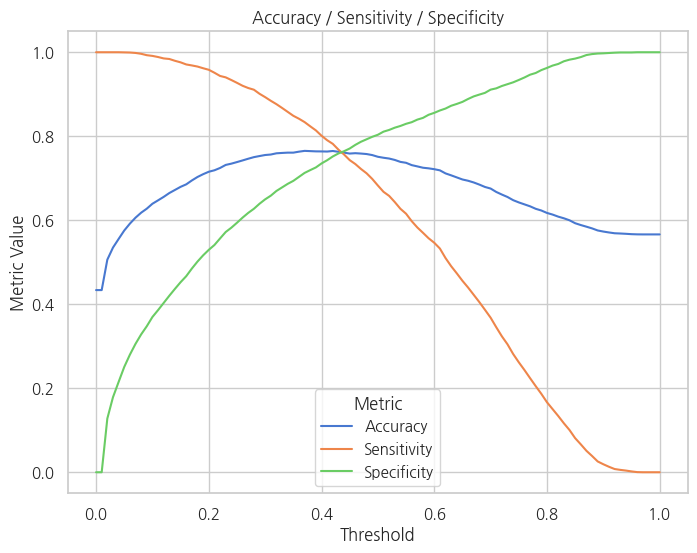

```python
metrics_long = metrics_logistic.melt(id_vars="Threshold",
                               value_vars=["Accuracy","Sensitivity","Specificity"],
                               var_name="Metric", value_name="Value")

plt.figure(figsize=(8,6))
sns.lineplot(data=metrics_long, x="Threshold", y="Value", hue="Metric", linewidth=1.5)
plt.xlabel("Threshold")
plt.ylabel("Metric Value")
plt.title("Accuracy / Sensitivity / Specificity")
plt.legend(title="Metric")
plt.show()
```

- ROC curve 를 계산 및 시각화하고 AUC 를 계산합니다. `sklearn.metrics`의 `roc_curve()` 함수를 이용하면 됩니다.

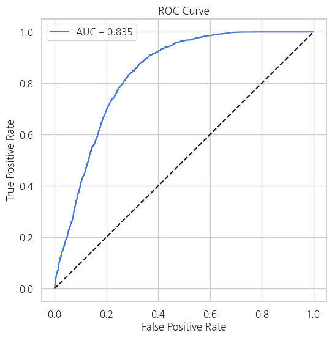

```python
fpr, tpr, _ = roc_curve(y_test, pred_logistic)
roc_auc = auc(fpr, tpr)

plt.figure(figsize=(6,6))
plt.plot(fpr, tpr, label=f"AUC = {roc_auc:.3f}")
plt.plot([0,1],[0,1],'k--')
plt.xlabel("False Positive Rate")
plt.ylabel("True Positive Rate")
plt.title("ROC Curve")
plt.legend()
plt.show()
```

# 연습 문제

- 똑같은 데이터를 사용합니다.

## 1. 로지스틱 회귀 모형

- 설명변수를 1개 사용하여 `bmi`를 설명변수로, `diabetes`를 반응변수로 하는 로지스틱 회귀모형을 적합합니다.
- 4단계에서 그린 BMI와 당뇨병 관계 시각화에 더해서 BMI 값 별로 로지스틱 회귀모형의 당뇨병 예측 확률을 곡선으로 그립니다. `sns.lineplot(x=hn19["diabetes"], y=pred_logistic)`과 같은 형태로 할 수 있습니다.

### 풀이

- `bmi`를 설명변수로, `diabetes`를 반응변수로 하는 로지스틱 회귀모형을 적합합니다.

```python
model_logistic_bmi = LogisticRegression(max_iter=1000)
model_logistic_bmi.fit(hn19[['bmi']], hn19['diabetes'])
```

```
LogisticRegression(max_iter=1000)
```

- `bmi`에 해당하는 격자를 `grid_bmi`로 생성합니다.
- 격자의 각 지점별 당뇨 확률을 계산해 `pred_logistic`에 저장합니다.

```python
grid_bmi = pd.DataFrame({'bmi': np.linspace(hn19['bmi'].min(), hn19['bmi'].max(), 100)})
pred_logistic = model_logistic_bmi.predict_proba(grid_bmi)[:, 1]
```

- 위의 BMI와 당뇨병 관계를 시각화는 코드를 가져오고, 여기에 회귀곡선을 시각화합니다. `grid_bmi`의 `bmi`에 격자가, `pred_logistic`에 당뇨 확률이 계산돼 있으므로 `sns.lineplot(x=grid_bmi['bmi'], y=pred_logistic)` 같은 식으로 코드를 작성하면 됩니다.

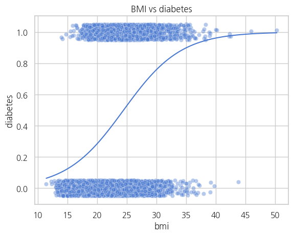

```python
y_jitter = hn19['diabetes'] + np.random.uniform(-0.05, 0.05, size=len(hn19))

sns.scatterplot(x='bmi', y=y_jitter, data=hn19, alpha=0.4)
sns.lineplot(x=grid_bmi['bmi'], y=pred_logistic)
plt.title("BMI vs diabetes")
plt.show()
```

## 2. 결정나무

- 설명변수를 1개 사용하여 `bmi`를 설명변수로, `diabetes`를 반응변수로 하는 분류 결정나무를 적합합니다. 가지치기는 따로 안해도 됩니다.
- 4단계에서 그린 BMI와 당뇨병 관계 시각화에 더해서 BMI 값 별로 분류 결정나무의 당뇨병 예측 확률을 곡선으로 그립니다. `sns.lineplot(x=hn19["diabetes"], y=pred_logistic)`과 같은 형태로 할 수 있습니다.

### 풀이

- `bmi`를 설명변수로, `diabetes`를 반응변수로 하는 분류 결정나무를 적합합니다.

```python
model_tree_bmi = DecisionTreeClassifier(max_depth=2, random_state=2025)
model_tree_bmi.fit(hn19[['bmi']], hn19['diabetes'])
```

```
DecisionTreeClassifier(max_depth=2, random_state=2025)
```

- 앞 문제의 `grid_bmi`를 `bmi`에 해당하는 격자로 활용합니다.
- 격자의 각 지점별 당뇨 확률을 계산해 `pred_tree`에 저장합니다.

```python
pred_tree = model_tree_bmi.predict_proba(grid_bmi)[:, 1]
```

- 위의 BMI와 당뇨병 관계를 시각화는 코드를 가져오고, 여기에 회귀곡선을 시각화합니다. `grid_bmi`의 `bmi`에 격자가, `pred_tree`에 당뇨 확률이 계산돼 있으므로 `sns.lineplot(x=grid_bmi['bmi'], y=pred_tree)` 같은 식으로 코드를 작성하면 됩니다.

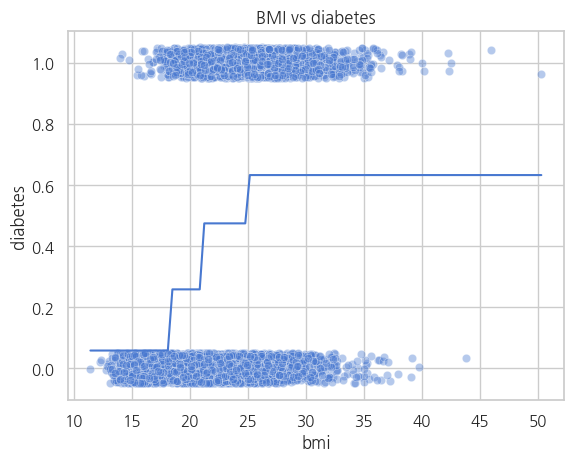

```python
y_jitter = hn19['diabetes'] + np.random.uniform(-0.05, 0.05, size=len(hn19))

sns.scatterplot(x='bmi', y=y_jitter, data=hn19, alpha=0.4)
sns.lineplot(x=grid_bmi['bmi'], y=pred_tree)
plt.title("BMI vs diabetes")
plt.show()
```

## 3. 배깅

- 설명변수를 2개 사용하여 `age`, `bmi`를 설명변수로, `diabetes`를 반응변수로 하는 배깅 모형을 적합합니다.
- 5단계 마지막에서 했던 것처럼 age 및 BMI 값 별로 배깅 모형의 당뇨병 예측 확률을 색칠해 나타냅니다.

### 풀이

- 우선 설명변수를 2개 사용하여 `age`, `bmi`를 설명변수로, `diabetes`를 반응변수로 하는 배깅 모형을 적합합니다.

```python
model_bag_2d = RandomForestClassifier(n_estimators=100, max_features=2, random_state=2025)
model_bag_2d.fit(hn19[['age','bmi']], hn19['diabetes'])
```

```
RandomForestClassifier(max_features=2, random_state=2025)
```

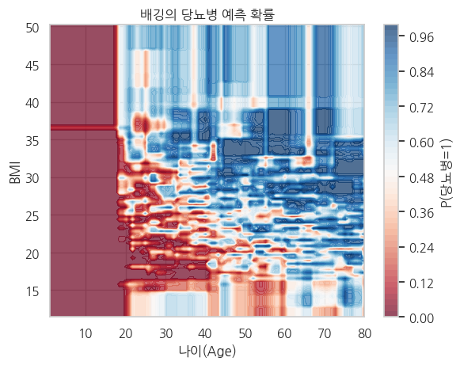

```python
# grid 생성
age_seq = np.linspace(hn19['age'].min(), hn19['age'].max(), 100)
bmi_seq = np.linspace(hn19['bmi'].min(), hn19['bmi'].max(), 100)
A, B = np.meshgrid(age_seq, bmi_seq)

grid = pd.DataFrame({'age': A.ravel(), 'bmi': B.ravel()})
pred_bag_2d = model_bag_2d.predict_proba(grid)[:, 1].reshape(A.shape)

contour = plt.contourf(A, B, pred_bag_2d, levels=50, cmap='RdBu', alpha=0.7)
plt.colorbar(contour, label="P(당뇨병=1)")
plt.xlabel("나이(Age)")
plt.ylabel("BMI")
plt.title("배깅의 당뇨병 예측 확률")
plt.show()
```

## 4. 랜덤 포레스트

- 설명변수를 2개 사용하여 `age`, `bmi`를 설명변수로, `diabetes`를 반응변수로 하는 랜덤 포레스트 모형을 적합합니다.
- 5단계 마지막에서 했던 것처럼 age 및 BMI 값 별로 랜덤 포레스트 모형의 당뇨병 예측 확률을 색칠해 나타냅니다.

### 풀이

- 우선 설명변수를 2개 사용하여 `age`, `bmi`를 설명변수로, `diabetes`를 반응변수로 하는 랜덤 포레스트 모형을 적합합니다.

```python
model_rf_2d = RandomForestClassifier(n_estimators=100, max_features=1, random_state=2025)
model_rf_2d.fit(hn19[['age','bmi']], hn19['diabetes'])
```

```
RandomForestClassifier(max_features=1, random_state=2025)
```

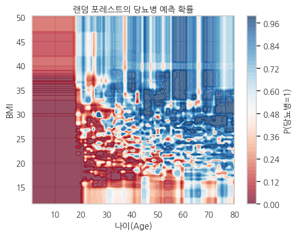

```python
# grid 생성
age_seq = np.linspace(hn19['age'].min(), hn19['age'].max(), 100)
bmi_seq = np.linspace(hn19['bmi'].min(), hn19['bmi'].max(), 100)
A, B = np.meshgrid(age_seq, bmi_seq)

grid = pd.DataFrame({'age': A.ravel(), 'bmi': B.ravel()})
pred_rf_2d = model_rf_2d.predict_proba(grid)[:, 1].reshape(A.shape)

contour = plt.contourf(A, B, pred_rf_2d, levels=50, cmap='RdBu', alpha=0.7)
plt.colorbar(contour, label="P(당뇨병=1)")
plt.xlabel("나이(Age)")
plt.ylabel("BMI")
plt.title("랜덤 포레스트의 당뇨병 예측 확률")
plt.show()
```

## 5. 인공 신경망

- 설명변수를 2개 사용하여 `age`, `bmi`를 설명변수로, `diabetes`를 반응변수로 하는 인공 신경망을 적합합니다.
- 5단계 마지막에서 했던 것처럼 age 및 BMI 값 별로 인공 신경망 모형의 당뇨병 예측 확률을 색칠해 나타냅니다.

### 풀이

- 우선 설명변수를 2개 사용하여 `age`, `bmi`를 설명변수로, `diabetes`를 반응변수로 하는 인공 신경망을 적합합니다.

```python
X_nn = hn19[['age','bmi']].iloc[0:100].values
y_nn = hn19['diabetes'].iloc[0:100].values

model_nn_2d = keras.Sequential([
    keras.layers.Dense(2, activation='relu', input_shape=(2,)),
    keras.layers.Dense(1, activation='sigmoid')
])
model_nn_2d.compile(optimizer='adam', loss='binary_crossentropy', metrics=['accuracy'])
model_nn_2d.fit(X_nn, y_nn, epochs=50, verbose=0)
print("신경망 정확도:", model_nn_2d.evaluate(X_nn, y_nn, verbose=0)[1])
```

```
신경망 정확도: 0.6499999761581421
```

```
313/313 ━━━━━━━━━━━━━━━━━━━━ 1s 2ms/step
```

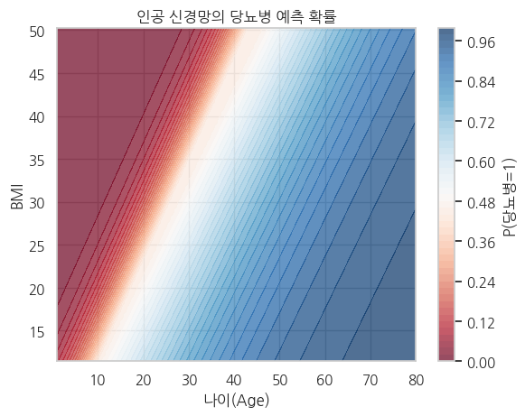

```python
# grid 생성
age_seq = np.linspace(hn19['age'].min(), hn19['age'].max(), 100)
bmi_seq = np.linspace(hn19['bmi'].min(), hn19['bmi'].max(), 100)
A, B = np.meshgrid(age_seq, bmi_seq)

grid = pd.DataFrame({'age': A.ravel(), 'bmi': B.ravel()})
pred_nn_2d = model_nn_2d.predict(grid).reshape(A.shape)

contour = plt.contourf(A, B, pred_nn_2d, levels=50, cmap='RdBu', alpha=0.7)
plt.colorbar(contour, label="P(당뇨병=1)")
plt.xlabel("나이(Age)")
plt.ylabel("BMI")
plt.title("인공 신경망의 당뇨병 예측 확률")
plt.show()
```

## 6. 모델 평가

- 설명변수를 3개 사용하여 `age`, `bmi`, `hp`를 설명변수로, `diabetes`를 반응변수로 하는 모형을 생각합니다.
- 위 실습에서는 로지스틱 회귀모형에 대해서 accuracy, sensitivity, specificity 의 곡선을 그리고 roc curve 를 그렸습니다. 이를 결정나무, 배깅, 랜덤 포레스트, 인공신경망에 대해 반복합니다.

### 풀이

- 앞에서처럼 학습용/테스트용 데이터(training data/test data)를 10% 대 90%로 분리합니다. `sklearn.model_selection`의 `train_test_split()` 함수를 사용합니다.

```python
train, test = train_test_split(hn19, test_size=0.9, random_state=2025)
X_train, y_train = train[['age','bmi','hp']], train['diabetes']
X_test, y_test = test[['age','bmi','hp']], test['diabetes']
```

- 앞에서 작성했던 threshold 별 평가 지표(accuracy, sensitivity, specificity)를 한 번에 계산하는 `calc_metrics` 함수를 가져옵니다.

```python
def calc_metrics(thresholds, actual, predicted_prob):
    results = []
    for t in thresholds:
        # 예측 확률이 threshold보다 크면 1(양성), 작으면 0(음성)
        pred_class = (predicted_prob > t).astype(int)

        # 혼동 행렬 요소 계산
        TP = np.sum((pred_class == 1) & (actual == 1))
        TN = np.sum((pred_class == 0) & (actual == 0))
        FP = np.sum((pred_class == 1) & (actual == 0))
        FN = np.sum((pred_class == 0) & (actual == 1))

        # 평가 지표 계산
        accuracy = (TP + TN) / (TP + TN + FP + FN)
        sensitivity = TP / (TP + FN) if (TP + FN) > 0 else 0
        specificity = TN / (TN + FP) if (TN + FP) > 0 else 0

        results.append((t, accuracy, sensitivity, specificity))
    return pd.DataFrame(results, columns=["Threshold","Accuracy","Sensitivity","Specificity"])
```

- 여기에 더해, accuracy, sensitivity, specificity 를 시각화하는 함수, roc curve 를 그리는 함수를 각각 만듭니다.

```python
def plot_metrics(thresholds, actual, predicted):
    metric = calc_metrics(thresholds, actual, predicted)

    metrics_long = metric.melt(id_vars="Threshold",
                               value_vars=["Accuracy","Sensitivity","Specificity"],
                               var_name="Metric", value_name="Value")

    plt.figure(figsize=(8,6))
    sns.lineplot(data=metrics_long, x="Threshold", y="Value", hue="Metric", linewidth=1.5)
    plt.xlabel("Threshold")
    plt.ylabel("Metric Value")
    plt.title("Accuracy / Sensitivity / Specificity")
    plt.legend(title="Metric")
    plt.show()

def plot_roc(actual, predicted):
    fpr, tpr, _ = roc_curve(actual, predicted)
    roc_auc = auc(fpr, tpr)

    plt.figure(figsize=(6,6))
    plt.plot(fpr, tpr, label=f"AUC = {roc_auc:.3f}")
    plt.plot([0,1],[0,1],'k--')
    plt.xlabel("False Positive Rate")
    plt.ylabel("True Positive Rate")
    plt.title("ROC Curve")
    plt.legend()
    plt.show()
```

- 앞에서처럼 thresholds 후보를 0부터 1까지 0.01 단위의 벡터로 만듭니다.

```python
thresholds = np.arange(0, 1.01, 0.01)
```

- 이제 결정나무에 대해 accuracy, sensitivity, specificity 의 곡선을 그리고 roc curve 를 그립니다.
- 학습 데이터(training data)에서 모형을 학습하고, 테스트 데이터(test data)에서 예측 확률을 산출합니다.

```python
model_tree = DecisionTreeClassifier(max_depth=2, random_state=2025)
model_tree.fit(X_train, y_train)
pred_tree = model_tree.predict_proba(X_test)[:, 1]
```

- 앞에서 작성한 `plot_metrics()` 함수로 threshold 변화 시 accuracy, sensitivity, specificity 를 시각화합니다.

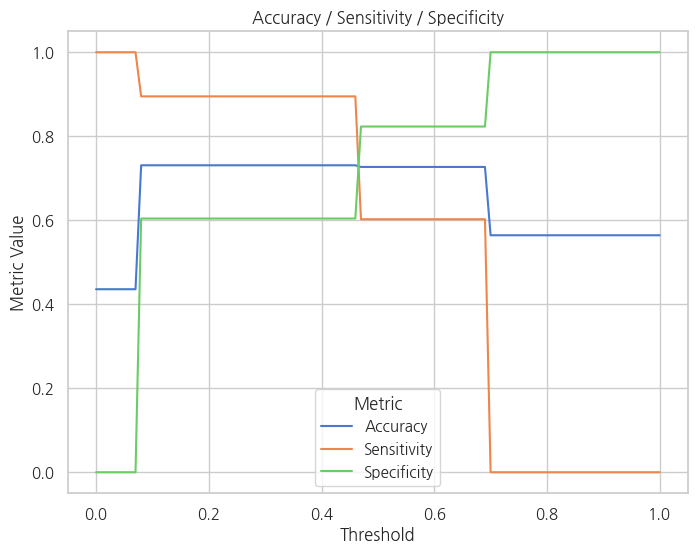

```python
plot_metrics(thresholds, y_test, pred_tree)
```

- ROC curve 를 계산 및 시각화하고 AUC 를 계산합니다.

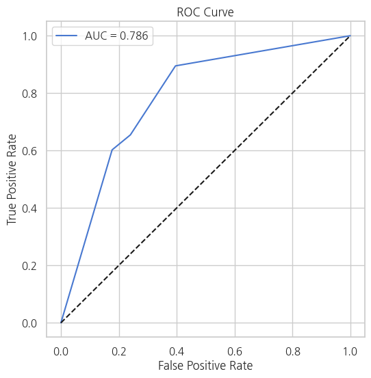

```python
plot_roc(y_test, pred_tree)
```

- 이제 배깅에 대해 accuracy, sensitivity, specificity 의 곡선을 그리고 roc curve 를 그립니다.
- 학습 데이터(training data)에서 모형을 학습하고, 테스트 데이터(test data)에서 예측 확률을 산출합니다.

```python
model_bag = RandomForestClassifier(n_estimators=100, max_features=3, random_state=2025)
model_bag.fit(X_train, y_train)
pred_bag = model_bag.predict_proba(X_test)[:, 1]
```

- 앞에서 작성한 `plot_metrics()` 함수로 threshold 변화 시 accuracy, sensitivity, specificity 를 시각화합니다.

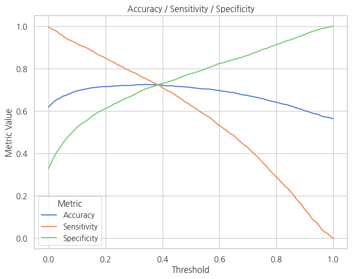

```python
plot_metrics(thresholds, y_test, pred_bag)
```

- ROC curve 를 계산 및 시각화하고 AUC 를 계산합니다.

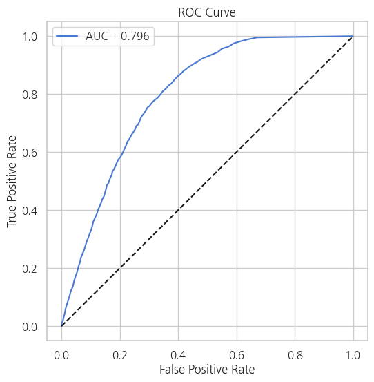

```python
plot_roc(y_test, pred_bag)
```

- 이제 랜덤포레스트에 대해 accuracy, sensitivity, specificity 의 곡선을 그리고 roc curve 를 그립니다.
- 학습 데이터(training data)에서 모형을 학습하고, 테스트 데이터(test data)에서 예측 확률을 산출합니다.

```python
model_rf = RandomForestClassifier(n_estimators=100, max_features=2, random_state=2025)
model_rf.fit(X_train, y_train)
pred_rf = model_rf.predict_proba(X_test)[:, 1]
```

- 앞에서 작성한 `plot_metrics()` 함수로 threshold 변화 시 accuracy, sensitivity, specificity 를 시각화합니다.

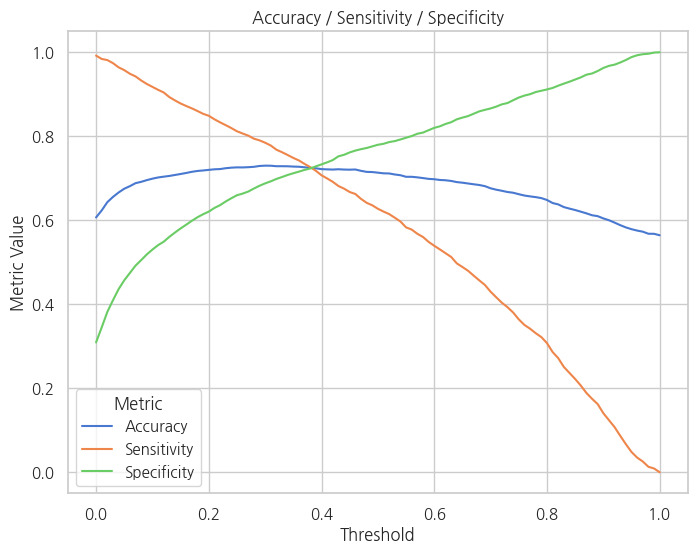

```python
plot_metrics(thresholds, y_test, pred_rf)
```

- ROC curve 를 계산 및 시각화하고 AUC 를 계산합니다.

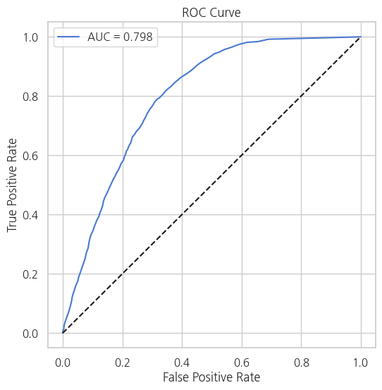

```python
plot_roc(y_test, pred_rf)
```

- 이제 배깅에 대해 accuracy, sensitivity, specificity 의 곡선을 그리고 roc curve 를 그립니다.
- 학습 데이터(training data)에서 모형을 학습하고, 테스트 데이터(test data)에서 예측 확률을 산출합니다.

```python
model_bag = RandomForestClassifier(n_estimators=100, max_features=3, random_state=2025)
model_bag.fit(X_train, y_train)
pred_bag = model_bag.predict_proba(X_test)[:, 1]
```

- 앞에서 작성한 `plot_metrics()` 함수로 threshold 변화 시 accuracy, sensitivity, specificity 를 시각화합니다.

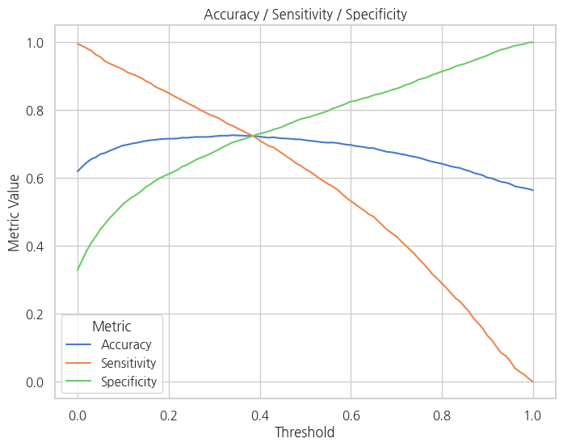

```python
plot_metrics(thresholds, y_test, pred_bag)
```

- ROC curve 를 계산 및 시각화하고 AUC 를 계산합니다.

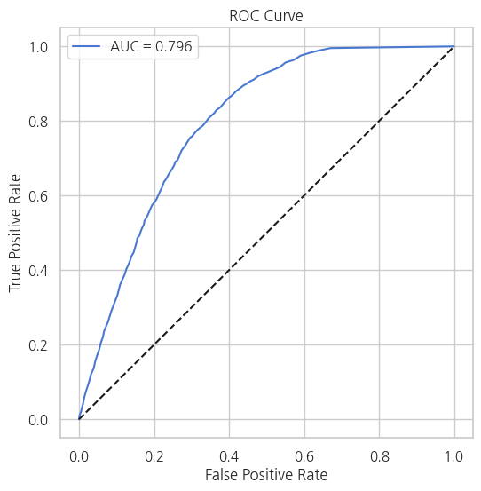

```python
plot_roc(y_test, pred_bag)
```

- 마지막으로 인공신경망에 대해 accuracy, sensitivity, specificity 의 곡선을 그리고 roc curve 를 그립니다.
- 학습 데이터(training data)에서 모형을 학습하고, 테스트 데이터(test data)에서 예측 확률을 산출합니다.

```python
model_nn = keras.Sequential([
    keras.layers.Dense(2, activation='relu', input_shape=(3,)),
    keras.layers.Dense(1, activation='sigmoid')
])
model_nn.compile(optimizer='adam', loss='binary_crossentropy', metrics=['accuracy'])
model_nn.fit(X_train, y_train, epochs=50, verbose=0)
pred_nn = model_nn.predict(X_test)[:, 0]
```

```
216/216 ━━━━━━━━━━━━━━━━━━━━ 2s 6ms/step
```

- 앞에서 작성한 `plot_metrics()` 함수로 threshold 변화 시 accuracy, sensitivity, specificity 를 시각화합니다.

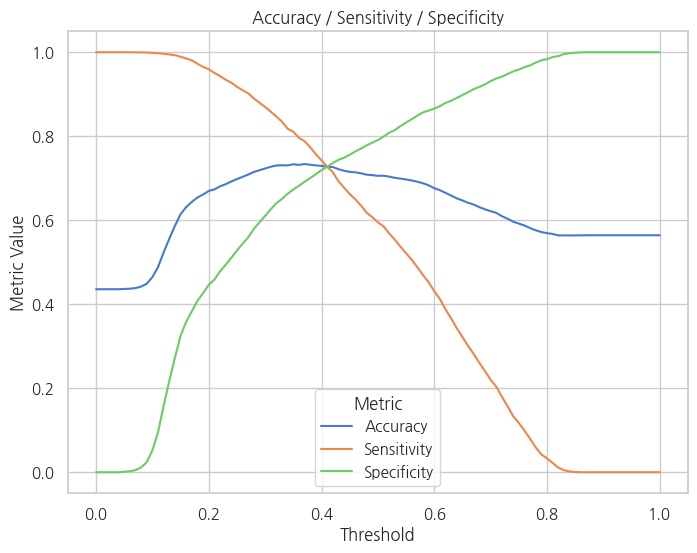

```python
plot_metrics(thresholds, y_test, pred_nn)
```

- ROC curve 를 계산 및 시각화하고 AUC 를 계산합니다.

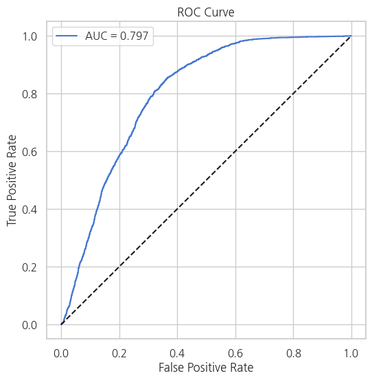

```python
plot_roc(y_test, pred_nn)
```